# GREENGrid Household Electricity Demand Data Circuit Extract Test: Heat Pump

Ben Anderson (b.anderson@soton.ac.uk, `@dataknut`)

Last run at: 2018-09-10 11:32:59

# 1 About

## 1.1 Report circulation:

- Public - this report is intended to accompany the data release.

## 1.2 License

This work is made available under the Creative Commons [Attribution-ShareAlike 4.0 International (CC BY-SA 4.0) License](https://creativecommons.org/licenses/by-sa/4.0/).

This means you are free to:

- *Share* — copy and redistribute the material in any medium or format
- *Adapt* — remix, transform, and build upon the material for any purpose, even commercially.

Under the following terms:

- *Attribution* — You must give appropriate credit, provide a link to the license, and indicate if changes were made. You may do so in any reasonable manner, but not in any way that suggests the licensor endorses you or your use.
- *ShareAlike* — If you remix, transform, or build upon the material, you must distribute your contributions under the same license as the original.
- *No additional restrictions* — You may not apply legal terms or technological measures that legally restrict others from doing anything the license permits.

**Notices:**

- You do not have to comply with the license for elements of the material in the public domain or where your use is permitted by an applicable exception or limitation.
- No warranties are given. The license may not give you all of the permissions necessary for your intended use. For example, other rights such as publicity, privacy, or moral rights may limit how you use the material. #YMMV

For the avoidance of doubt and explanation of terms please refer to the full [license notice](https://creativecommons.org/licenses/by-sa/4.0/) and [legal code](https://creativecommons.org/licenses/by-sa/4.0/legalcode).

## 1.3 Citation

If you wish to use any of the material from this report please cite as:

- Anderson, B. (2018) GREENGrid Household Electricity Demand Data Circuit Extract Test: Heat Pump. [Centre for Sustainability](http://www.otago.ac.nz/centre-sustainability/), University of Otago: Dunedin.

This work is (c) 2018 the University of Southampton.

## 1.4 History

- [Report history](https://github.com/CfSOtago/GREENGridData/commits/master/examples/testHeatPumpExtract.Rmd)

## 1.5 Requirements:

This report uses the safe version of the grid spy 1 minute data which has been processed using the code in https://github.com/CfSOtago/GREENGridData/tree/master/dataProcessing/gridSpy. It also assumes you have already run the example circuit extraction script using circuit = Heat Pump.

## 1.6 Support

This work was supported by:

- The [University of Otago](https://www.otago.ac.nz/);
- The [University of Southampton](https://www.southampton.ac.uk/);
- The New Zealand [Ministry of Business, Innovation and Employment (MBIE)](http://www.mbie.govt.nz/) through the [NZ GREEN Grid](https://www.otago.ac.nz/centre-sustainability/research/energy/otago050285.html) grant (Contract ID: UOCX1203);
- [SPATIALEC](http://www.energy.soton.ac.uk/tag/spatialec/) - a [Marie Skłodowska-Curie Global Fellowship](http://ec.europa.eu/research/mariecurieactions/about-msca/actions/if/index_en.htm) based at the University of Otago’s [Centre for Sustainability](http://www.otago.ac.nz/centre-sustainability/staff/otago673896.html) (2017-2019) & the University of Southampton’s Sustainable Energy Research Group (2019-202).

# 2 Introduction

The [NZ GREEN Grid household electricity demand study](https://cfsotago.github.io/GREENGridData/) recruited a sample of c 25 households in each of two regions of New Zealand (Stephenson et al. 2017). The first sample was recruited in early 2014 and the second in early 2015. Research data includes:

- 1 minute electricity power (W) data was collected for each dwelling circuit using [GridSpy](https://gridspy.com/) monitors on each power circuit (and the incoming power). The power values represent mean(W) over the minute preceeding the observation timestamp;
- Dwelling & appliance surveys;
- Occupant time-use diaries (focused on energy use).

NB: Version 1 of the data package does not include the time-use diaries.

This report provides summary analysis of one circuit type (Heat Pump) across all households as an example.

# 3 Load data

The data used to generate this report is:

- /Volumes/hum-csafe/Research Projects/GREEN Grid/cleanData/safe/gridSpy/1min/dataExtracts/Heat Pump_2015-04-01_2016-03-31_observations.csv.gz
- /Volumes/hum-csafe/Research Projects/GREEN Grid/cleanData/safe/survey/ggHouseholdAttributesSafe.csv

First we load the household data. `readr` will give some feedback on the columns.

Next we load the Grid Spy extract for Heat Pump. This uses a `GREENGridData` package function intended to load the cleaned individual household data which warns that two of the column names are not found. These columns were dropped during the extraction process so we can safely ignore these warnings

```
## Warning: The following named parsers don't match the column names:
## dateTime_orig, TZ_orig
```

Table 3.1: First few rows of grid spy data

| hhID | linkID | r_dateTime | circuit | powerW |
| --- | --- | --- | --- | --- |
| rf_08 | rf_08 | 2015-04-01 00:00:00 | Heat Pump$2092 | 0 |
| rf_08 | rf_08 | 2015-04-01 00:01:00 | Heat Pump$2092 | 0 |
| rf_08 | rf_08 | 2015-04-01 00:02:00 | Heat Pump$2092 | 0 |
| rf_08 | rf_08 | 2015-04-01 00:03:00 | Heat Pump$2092 | 0 |
| rf_08 | rf_08 | 2015-04-01 00:04:00 | Heat Pump$2092 | 0 |
| rf_08 | rf_08 | 2015-04-01 00:05:00 | Heat Pump$2092 | 0 |

Table 3.1 shows the first few rows of the Grid Spy 1 minute power data.

Table 3.2: Summary of grid spy data

[output not shown]

[output not shown]

[output not shown]

Length:14250284

Length:14250284

Class :character

Class :character

1st Qu.:2015-06-22 12:39:00

Class :character

1st Qu.: 0.00

Mode :character

Mode :character

Median :2015-09-16 13:12:00

Mode :character

Median : 0.00

NA

NA

Mean :2015-09-21 08:00:39

NA

Mean : 147.92

NA

NA

3rd Qu.:2015-12-17 17:52:00

NA

3rd Qu.: 61.29

NA

NA

Max. :2016-03-31 23:59:00

NA

Max. :27759.00

Table 3.2 shows a summary of the Grid Spy 1 minute power data.

Note that:

- r_datetime is the correct dateTime of each observation in UTC and will have loaded as your local timezone. If you are conducting this analysis outside NZ then you will get strange results until you use [lubridate](https://lubridate.tidyverse.org/) to tell R to use tz = “Pacific/Auckland” with this variable;
- there can be 0 Wh observations.

# 4 Plot seasonal mean power profiles

First we create a *Southern* Hemisphere season variable. Luckily we have a function to do this in the `GREENGridData` package. We print a check table to ensure we are all happy with the coding of `season`.

```r
gsDT <- GREENGridData::addNZSeason(gsDT)
table(lubridate::month(gsDT$r_dateTime, label = TRUE), gsDT$season, useNA = "always")
```

```
##
##         Spring  Summer  Autumn  Winter    <NA>
##   Jan        0 1047915       0       0       0
##   Feb        0  992190       0       0       0
##   Mar        0       0 1041934       0       0
##   Apr        0       0 1267073       0       0
##   May        0       0 1351744       0       0
##   Jun        0       0       0 1309730       0
##   Jul        0       0       0 1305957       0
##   Aug        0       0       0 1250152       0
##   Sep  1225729       0       0       0       0
##   Oct  1246542       0       0       0       0
##   Nov  1140896       0       0       0       0
##   Dec        0 1070422       0       0       0
##   <NA>       0       0       0       0       0
```

## 4.1 Overall profiles

This section plots overall mean power per minute by season.

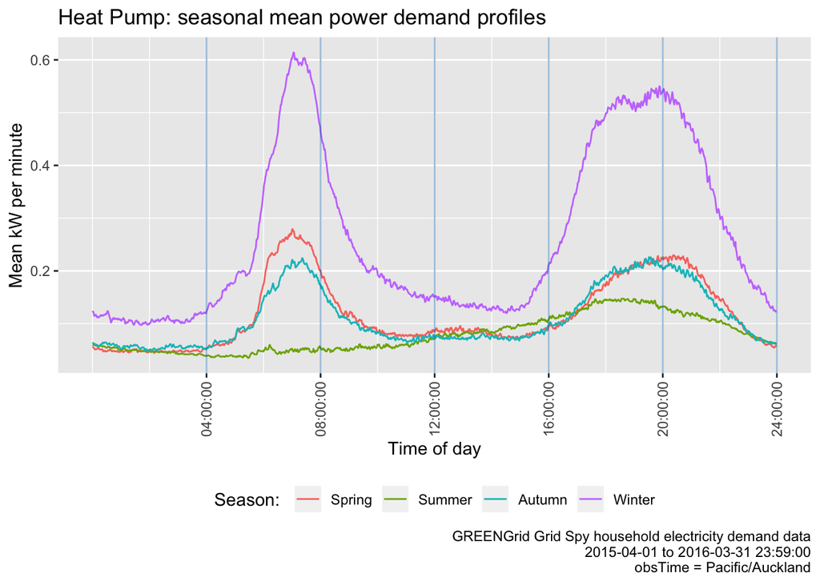

Figure 4.1: Demand profile plot

```r
plotDT <- gsDT[, .(meanW = mean(powerW)), keyby = .(season, obsTime)
             ]

# set attributes for plot
vLineAlpha <- 0.4
vLineCol <- "#0072B2" # http://www.cookbook-r.com/Graphs/Colors_(ggplot2)/#a-colorblind-friendly-palette
timeBreaks <- c(hms::as.hms("04:00:00"),
                hms::as.hms("08:00:00"),
                hms::as.hms("12:00:00"),
                hms::as.hms("16:00:00"),
                hms::as.hms("20:00:00"),
                hms::as.hms("24:00:00")
)

myPlot <- ggplot2::ggplot(plotDT[!is.na(season)], # make sure no un-set seasons/non-parsed dates
                          aes(x = obsTime, y = meanW/1000, colour = season)) +
  geom_line() +
  theme(strip.text.y = element_text(angle = 0, vjust = 0.5, hjust = 0.5)) +
  theme(axis.text.x = element_text(angle = 90, vjust = 0.5, hjust = 0.5)) +
  guides(colour = guide_legend(title = "Season: ")) +
  theme(legend.position = "bottom")  +
  labs(title = paste0(params$circuit, ": seasonal mean power demand profiles"),
       y = "Mean kW per minute",
       x = "Time of day",
       caption = paste0("GREENGrid Grid Spy household electricity demand data",
                        "\n", min(gsDT$r_dateTime),
                        " to ", max(gsDT$r_dateTime),
                        "\nobsTime = Pacific/Auckland"))

myPlot +
  scale_x_time(breaks = timeBreaks) +
  geom_vline(xintercept = timeBreaks, alpha = vLineAlpha, colour = vLineCol)
```

```r
ggsave(paste0(params$circuit, "_meankWperminBySeason.png"))
```

Figure 4.1 shows the overall mean kW per minute in each season for this circuit (Heat Pump).

## 4.2 Profiles by linked household attributes

This section plots overall mean power per minute by season and number of children aged 0-12 as an illustration of how to link the Grid Spy and household data. We will go through the steps with commentary and showing the code…

Table 4.1 the number of households who have different numbers of children aged 0-12 so we know how many households make up each line on the plot. This table includes households where we do not know the number of children (NA) but we do have electricity demand data.

Table 4.1: Number of households with children aged 0-12

| nChildren0_12 | Freq |
| --- | --- |
| NA | 2 |
| 0 | 17 |
| 1 | 11 |
| 2 | 10 |
| 3 | 4 |

Now we link (join) the Grid Spy and household data.tables and aggregate (summarise) by season and number of children aged 0-12. You can do this using `data.table`’s on the fly [join](https://cran.r-project.org/web/packages/data.table/vignettes/datatable-faq.html#MergeDiff) but we have found pre-joining of the columns you want to be much faster. We have wrapped both methods inside `system.time()` calls for comparison.

You can probably also do this in `dplyr` etc but we haven’t tried.

```r
print("data.table join on the fly (version 1 - slow):")
```

```
## [1] "data.table join on the fly (version 1 - slow):"
```

```r
system.time(plotDT <- gsDT[hhDT][, .(meanW = mean(powerW)), keyby = .(season, obsTime, nChildren0_12)
             ]) # aggregate by season, time and n children aged 0 - 12
```

```
##    user  system elapsed
##  25.272   4.019  31.672
```

```r
# print("data.table join on the fly (version 2):")
# # appears to be as specified in https://cran.r-project.org/web/packages/data.table/vignettes/datatable-faq.html#MergeDiff
# # but fails to find nChildren0_12
# system.time(plotDT <- gsDT[hhDT, .(meanW = mean(powerW)), keyby = .(season, obsTime, nChildren0_12)
#              ]) # aggregate by season, time and n children aged 0 - 12

aggFunc <- function(gsDT, hhDT){
  # do it in stages instead
  keepCols <- c("linkID", "nChildren0_12")
  mergedDT <- gsDT[hhDT[, ..keepCols]]
  dt <- mergedDT[, .(meanW = mean(powerW)), keyby = .(season, obsTime, nChildren0_12)]
  return(dt)
}
print("data.table join then aggregate:")
```

```
## [1] "data.table join then aggregate:"
```

```r
system.time(plotDT <- aggFunc(gsDT, hhDT))
```

```
##    user  system elapsed
##   2.983   0.211   3.235
```

Now use the aggregated `data.table` to make the plot. Note that as specified this will add a line for nChildren0_12 == NA household(s) - see Table 4.1.

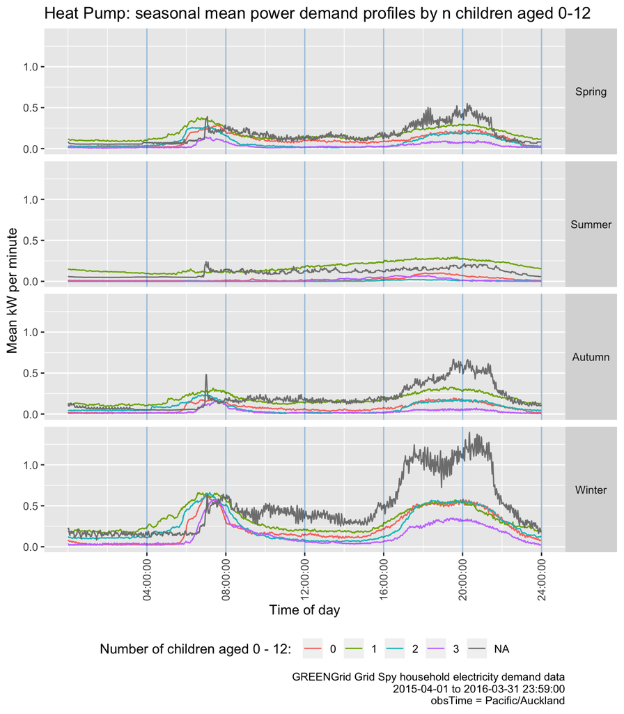

Figure 4.2: Demand profile plot

```r
myPlot <- ggplot2::ggplot(plotDT[!is.na(season)], # make sure no un-set seasons/non-parsed dates
                          aes(x = obsTime, y = meanW/1000,
                              colour = as.factor(nChildren0_12))) +
  geom_line() +
  facet_grid(season  ~ .) +
  theme(strip.text.y = element_text(angle = 0, vjust = 0.5, hjust = 0.5)) +
  theme(axis.text.x = element_text(angle = 90, vjust = 0.5, hjust = 0.5)) +
  guides(colour = guide_legend(title = "Number of children aged 0 - 12: ")) +
  theme(legend.position = "bottom")  +
  labs(title = paste0(params$circuit, ": seasonal mean power demand profiles by n children aged 0-12"),
       y = "Mean kW per minute",
       x = "Time of day",
       caption = paste0("GREENGrid Grid Spy household electricity demand data",
                        "\n", min(gsDT$r_dateTime),
                        " to ", max(gsDT$r_dateTime),
                        "\nobsTime = Pacific/Auckland"))

myPlot +
  scale_x_time(breaks = timeBreaks) +
  geom_vline(xintercept = timeBreaks, alpha = vLineAlpha, colour = vLineCol)
```

```r
ggsave(paste0(params$circuit, "_meankWperminBySeason_nKids0-12.png"))
```

Figure 4.2 shows the mean kW per minute per season by presence of young children for this circuit (Heat Pump). Can you see anything interesting or unusual and might this be due to the numbers of households in each group?

# 5 Runtime

Analysis completed in 104.6 seconds ( 1.74 minutes) using knitr in [RStudio](http://www.rstudio.com) with R version 3.5.1 (2018-07-02) running on x86_64-apple-darwin15.6.0.

# 6 R environment

## 6.1 R packages used

- base R (R Core Team 2016)
- bookdown (Xie 2016a)
- GREENGridData (Anderson and Eyers 2018) which depends on:
  - data.table (Dowle et al. 2015)
  - dplyr (Wickham and Francois 2016)
  - hms (Müller 2018)
  - lubridate (Grolemund and Wickham 2011)
  - progress (Csárdi and FitzJohn 2016)
  - readr (Wickham, Hester, and Francois 2016)
  - readxl (Wickham and Bryan 2017)
  - reshape2 (Wickham 2007)
- kableExtra (Zhu 2018)
- knitr (Xie 2016b)
- rmarkdown (Allaire et al. 2018)

# References

Allaire, JJ, Yihui Xie, Jonathan McPherson, Javier Luraschi, Kevin Ushey, Aron Atkins, Hadley Wickham, Joe Cheng, and Winston Chang. 2018. *Rmarkdown: Dynamic Documents for R*. https://CRAN.R-project.org/package=rmarkdown.

Anderson, Ben, and David Eyers. 2018. *GREENGridData: Processing Nz Green Grid Project Data to Create a ’Safe’ Version for Data Archiving and Re-Use*. https://github.com/CfSOtago/GREENGridData.

Csárdi, Gábor, and Rich FitzJohn. 2016. *Progress: Terminal Progress Bars*. https://CRAN.R-project.org/package=progress.

Dowle, M, A Srinivasan, T Short, S Lianoglou with contributions from R Saporta, and E Antonyan. 2015. *Data.table: Extension of Data.frame*. https://CRAN.R-project.org/package=data.table.

Grolemund, Garrett, and Hadley Wickham. 2011. “Dates and Times Made Easy with lubridate.” *Journal of Statistical Software* 40 (3): 1–25. http://www.jstatsoft.org/v40/i03/.

Müller, Kirill. 2018. *Hms: Pretty Time of Day*. https://CRAN.R-project.org/package=hms.

R Core Team. 2016. *R: A Language and Environment for Statistical Computing*. Vienna, Austria: R Foundation for Statistical Computing. https://www.R-project.org/.

Stephenson, Janet, Rebecca Ford, Nirmal-Kumar Nair, Neville Watson, Alan Wood, and Allan Miller. 2017. “Smart Grid Research in New Zealand–A Review from the GREEN Grid Research Programme.” *Renewable and Sustainable Energy Reviews* 82 (1): 1636–45. https://doi.org/10.1016/j.rser.2017.07.010.

Wickham, Hadley. 2007. “Reshaping Data with the reshape Package.” *Journal of Statistical Software* 21 (12): 1–20. http://www.jstatsoft.org/v21/i12/.

Wickham, Hadley, and Jennifer Bryan. 2017. *Readxl: Read Excel Files*. https://CRAN.R-project.org/package=readxl.

Wickham, Hadley, and Romain Francois. 2016. *Dplyr: A Grammar of Data Manipulation*. https://CRAN.R-project.org/package=dplyr.

Wickham, Hadley, Jim Hester, and Romain Francois. 2016. *Readr: Read Tabular Data*. https://CRAN.R-project.org/package=readr.

Xie, Yihui. 2016a. *Bookdown: Authoring Books and Technical Documents with R Markdown*. Boca Raton, Florida: Chapman; Hall/CRC. https://github.com/rstudio/bookdown.

———. 2016b. *Knitr: A General-Purpose Package for Dynamic Report Generation in R*. https://CRAN.R-project.org/package=knitr.

Zhu, Hao. 2018. *KableExtra: Construct Complex Table with ’Kable’ and Pipe Syntax*. https://CRAN.R-project.org/package=kableExtra.